# Analyze_ab_test_results_notebook maincopy-Copy1

## Analyze A/B Test Results

- Introduction
- Part I - Probability
- Part II - A/B Test
- Part III - Regression

### Introduction

The data for this project is provided by Udacity as a part of [Data Analyst Nanodegree](https://www.udacity.com/course/data-analyst-nanodegree--nd002?) program. The dataset contains results of an A/B test run by an e-commerce website. I analyze the dataset to help the company understand if they should implement the new page, keep the old page, or perhaps run the experiment longer to make their decision.

#### Part I - Probability

To get started, let's import our libraries.

```python
import pandas as pd
import numpy as np
import random
import matplotlib.pyplot as plt
%matplotlib inline
random.seed(42)
```

`1.` I read in the `ab_data.csv` data and store it in `df`.

a. I read in the dataset and examine the top few rows

```python
df = pd.read_csv('ab_data.csv')
df.head()
```

|  | user_id | timestamp | group | landing_page | converted |
| --- | --- | --- | --- | --- | --- |
| 0 | 851104 | 2017-01-21 22:11:48.556739 | control | old_page | 0 |
| 1 | 804228 | 2017-01-12 08:01:45.159739 | control | old_page | 0 |
| 2 | 661590 | 2017-01-11 16:55:06.154213 | treatment | new_page | 0 |
| 3 | 853541 | 2017-01-08 18:28:03.143765 | treatment | new_page | 0 |
| 4 | 864975 | 2017-01-21 01:52:26.210827 | control | old_page | 1 |

b. Number of rows in the dataset

```python
df.shape[0]
```

```
294478
```

c. The number of unique users in the dataset.

```python
df.user_id.nunique()
```

```
290584
```

d. The proportion of users converted.

```python
df.converted.mean()
```

```
0.11965919355605512
```

e. The number of times the `new_page` and `treatment` don't match.

```python
mismatch1 = df[(df['group']=='treatment') \
               & (df['landing_page']=='old_page')]
```

```python
mismatch2 = df[(df['group']=='control') \
               & (df['landing_page']=='new_page')]
```

```python
mismatch = mismatch1['user_id'].count() + mismatch2['user_id'].count()
mismatch
```

```
3893
```

new_page and treatment don't match 3893 times

f. Checking to see if any of the rows have missing values

```python
df.info()
```

```
<class 'pandas.core.frame.DataFrame'>
RangeIndex: 294478 entries, 0 to 294477
Data columns (total 5 columns):
user_id         294478 non-null int64
timestamp       294478 non-null object
group           294478 non-null object
landing_page    294478 non-null object
converted       294478 non-null int64
dtypes: int64(2), object(3)
memory usage: 11.2+ MB
```

All the columns have 294478 non-null values. Hence, no row has missing values.

`2.` For the rows where **treatment** does not match with **new_page** or **control** does not match with **old_page**, I cannot be sure if this row truly received the new or old page.

a. As the number of rows that mismatch (3893) are a small sample out of 294478 total rows, I will delete the rows which mismatch and store the new dataframe in **df2**.

```python
df2 = df.drop(mismatch1.index)
df2 = df2.drop(mismatch2.index)
```

```python
df2.shape
```

```
(290585, 5)
```

```python
# Double Check all of the correct rows were removed - this should be 0
df2[((df2['group'] == 'treatment') == (df2['landing_page'] == 'new_page')) == False].shape[0]
```

```
0
```

`3.` Analyzing the dataframe **df2**

a. Number of unique **user_id**s are in **df2**

```python
df2['user_id'].nunique()
```

```
290584
```

b. One **user_id** repeated in **df2**

```python
df2[df2['user_id'].duplicated()]
```

|  | user_id | timestamp | group | landing_page | converted |
| --- | --- | --- | --- | --- | --- |
| 2893 | 773192 | 2017-01-14 02:55:59.590927 | treatment | new_page | 0 |

c. Row information for the repeat **user_id**

```python
df2[df2['user_id'].duplicated(keep=False)]
```

|  | user_id | timestamp | group | landing_page | converted |
| --- | --- | --- | --- | --- | --- |
| 1899 | 773192 | 2017-01-09 05:37:58.781806 | treatment | new_page | 0 |
| 2893 | 773192 | 2017-01-14 02:55:59.590927 | treatment | new_page | 0 |

d. I remove **one** of the rows with a duplicate **user_id**

```python
df2 = df2.drop(2893)
```

```python
df2.shape #to check no. of rows in df2
```

```
(290584, 5)
```

`4.` Calculating the summary statistics and probability

a. Probability of an individual converting regardless of the page they receive

```python
df2['converted'].mean()
```

```
0.11959708724499628
```

b. Conditional probability that the individual converted given that an individual was in the `control` group

```python
df2.query('group == "control"')['converted'].mean()
```

```
0.1203863045004612
```

c. Conditional probability that the individual converted given that an individual was in the `treatment` group

```python
df2.query('group == "treatment"')['converted'].mean()
```

```
0.11880806551510564
```

d. Probability that an individual received the new page

```python
df2.query('landing_page == "new_page"')['user_id'].count()/df2.shape[0]
```

```
0.50006194422266881
```

e. Based on your results from parts (a) through (d) above, is sufficient evidence to conclude that the new treatment page leads to more conversions?

There is **not sufficient** evidence to conclude that the new treatment page leads to more conversions.

The probability that the individual receives new page is 50%. This means there is a an equal probability whether the individual could receive an old page or new page.

The probability of an individual converting regardless of the page they receive is 11.96%. The probability of converting given the individual received the new page (treatment group) is 11.88%. This probability is marginally less than the probability of individual converting given they received the old page (control group) which is 12.04%.

Hence, it seems that the new page did not make any difference to the conversion rate of individuals.

### Part II - A/B Test

As there is a time stamp associated with each event, technically hypothesis test could run continuously as each observation was observed.

`1.` As I need to make the decision just based on all the data provided, I will assume that the old page is better unless the new page proves to be definitely better at a Type I error rate of 5%

I define the null and alternative hypotheses using **$p_{old}$** and **$p_{new}$**, which are the converted rates for the old and new pages.

**Hypothesis Statement**

H0: The mean converted rate for the new page is less than or equal to the mean converted rate for the old page, i.e. $𝑝_{𝑛𝑒𝑤}$ <= $𝑝_{𝑜𝑙𝑑}$.

Alternatively, $𝑝_{𝑛𝑒𝑤}$ - $𝑝_{𝑜𝑙𝑑}$ <= 0

H1: The mean converted rate for the new page is greater than the mean converted rate for the old page, i.e. $𝑝_{𝑛𝑒𝑤}$ > $𝑝_{𝑜𝑙𝑑}$.

Alternatively, $𝑝_{𝑛𝑒𝑤}$ - $𝑝_{𝑜𝑙𝑑}$ > 0

`2.` I assume under the null hypothesis, $p_{new}$ and $p_{old}$ both have "true" success rates equal to the **converted** success rate regardless of page - that is $p_{new}$ and $p_{old}$ are equal. I assume they are equal to the **converted** rate in **ab_data.csv** regardless of the page.

I use a sample size for each page equal to the ones in **ab_data.csv**.

Next, I perform the sampling distribution for the difference in **converted** between the two pages over 10,000 iterations of calculating an estimate from the null.

a. The **conversion rate** for $p_{new}$ under the null

```python
cr_new = df2['converted'].mean()
cr_new
```

```
0.11959708724499628
```

b. The **conversion rate** for $p_{old}$ under the null

```python
cr_old = df2['converted'].mean()
cr_old
```

```
0.11959708724499628
```

c. The number of individuals in the treatment group, $n_{new}$

```python
n_new = df2.query('group == "treatment"')['user_id'].count()
n_new
```

```
145310
```

d. The number of individuals in the control group, $n_{old}$

```python
n_old = df2.query('group == "control"')['user_id'].count()
n_old
```

```
145274
```

e. Simulating $n_{new}$ transactions with a conversion rate of $p_{new}$ under the null. Storing these $n_{new}$ 1's and 0's in **new_page_converted**.

```python
new_page_converted = np.random.choice([1,0], n_new, p=[cr_new, 1-cr_new])
new_page_converted
```

```
array([0, 0, 0, ..., 0, 0, 0])
```

f. Simulating $n_{old}$ transactions with a conversion rate of $p_{old}$ under the null. Storing these $n_{old}$ 1's and 0's in **old_page_converted**.

```python
old_page_converted = np.random.choice([1,0], n_old, p=[cr_old, 1-cr_old])
old_page_converted
```

```
array([0, 0, 1, ..., 0, 0, 0])
```

g. Next, I calculate $p_{new}$ - $p_{old}$ for the simulated values from part (e) and (f).

```python
new_page_converted.mean() - old_page_converted.mean()
```

```
-0.00071798184598828585
```

h. Now, I create 10,000 $p_{new}$ - $p_{old}$ values using the same simulation process used in parts (a) through (g) above and store all 10,000 values in a NumPy array called **p_diffs**.

```python
# p_diffs = []
# for _ in range(10000):
#     new_page_converted = np.random.choice([1, 0], size=n_new, p=[cr_new, 1-cr_new])
#     old_page_converted = np.random.choice([1, 0], size=n_old, p=[cr_old, 1-cr_old])
#     p_diffs.append(new_page_converted.mean() - old_page_converted.mean())
```

One method to create 10,000 simulations would be to run a loop. A faster method to stimulate transactions is to use np.random.binomial.

```python
new_page_converted_simulated = np.random.binomial(n_new, cr_new, 10000)/n_new
old_page_converted_simulated = np.random.binomial(n_old, cr_old, 10000)/n_old
p_diffs = new_page_converted_simulated - old_page_converted_simulated
```

```python
p_diffs
```

```
array([ -1.28222271e-03,  -1.06901020e-03,  -1.59887256e-03, ...,
        -8.48305040e-05,  -3.65911227e-05,  -2.77694234e-04])
```

i. I plot a histogram of the **p_diffs** to see if it looks like what I expected

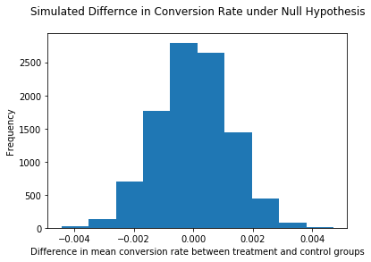

```python
plt.hist(p_diffs)
plt.title('Simulated Differnce in Conversion Rate under Null Hypothesis\n', fontsize = 12)
plt.xlabel('Difference in mean conversion rate between treatment and control groups')
plt.ylabel('Frequency');
```

As expected, the simulated difference in conversion rate under null hypothesis follows a normal distribution.

j. Calculating the proportion of the **p_diffs** that are greater than the actual difference observed in **ab_data.csv**

```python
df_control = df2.query('group == "control"')
df_treatment = df2.query('group == "treatment"')

# Actual difference observed between the conversion rate for new page and old page
obs_diff = df_treatment.converted.mean() - df_control.converted.mean()
obs_diff
```

```
-0.0015782389853555567
```

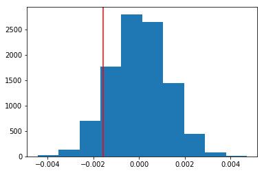

```python
plt.hist(p_diffs)
plt.axvline(obs_diff, color='r');
```

```python
p_value = (p_diffs > obs_diff).mean()
p_value
```

```
0.90159999999999996
```

```python
print(f'{p_value*100}% of the p_diffs are greater than the actual difference observed in ab_data.csv')
```

```
90.16% of the p_diffs are greater than the actual difference observed in ab_data.csv
```

k. Interpreting the results

p value is the probability of observing our statistic in favor of alternative hypothesis if null hypothesis is true.

Since the p value (0.90) is greater than the threshold for Type I error rate of 0.05, we fail to reject the Null Hypothesis.

The conversion rate for the new page is less than or equal to the conversion rate for old page.

l. Using statsmodel Python package to test the hypothesis.

I calculate the number of conversions for each page, as well as the number of individuals who received each page. Let `n_old` and `n_new` refer the the number of rows associated with the old page and new pages, respectively.

```python
import statsmodels.api as sm

convert_old = df2.query('group=="control"')['converted'].sum()
convert_new = df2.query('group=="treatment"')['converted'].sum()
n_old = df2.query('group=="control"')['user_id'].count()
n_new = df2.query('group=="treatment"')['user_id'].count()
print('Number of conversions for old page is {} \nand the number of conversions for new page is {}'\
      .format(convert_old, convert_new))
print('\n')
print('Number of users who receive old page is {} \nand number of users who receive new page is {}'\
      .format(n_old, n_new))
```

```
Number of conversions for old page is 17489
and the number of conversions for new page is 17264


Number of users who receive old page is 145274
and number of users who receive new page is 145310
```

m. I use use `stats.proportions_ztest` to compute the test statistic and p-value

```python
# For one-sided z-test, alternative is selected as 'larger' as the alternative hypothesis is of the form  prop > value
stat, pval = sm.stats.proportions_ztest([convert_new, convert_old], [n_new, n_old], alternative='larger')
print(f'The value of statistic for z-test (or z-score) is {stat} \nand p value for the z-test is {pval}')
```

```
The value of statistic for z-test (or z-score) is -1.3109241984234394
and p value for the z-test is 0.9050583127590245
```

```python
from scipy.stats import norm

print(f'z-critival value is {norm.ppf(1-(0.05))}') # Tells us the critical value at 95% confidence interval
```

```
z-critival value is 1.6448536269514722
```

n. Interpretation of the z-score and p-value

For alpha level, 0.05, the z-critical value is 1.65. Since, z-score (-1.31) is less than the z-critical value, we fail to reject the Null Hypothesis.

The p value is greater than the alpha level (0.05). Therefore, we fail to reject the Null Hypothesis. There is no significant evidence that the new page is better than the old page. The analysis is similar to the analysis performed in part j. and k.

### Part III - A regression approach

`1.` In this part of the project, I used regression models to analyze the results.  
a. Type of regression

Since the rows contain only two possible outcomes (conversion or no conversion), I will use Logistic Regression.

Logistic Regression is used to perform a regression to predict categorical response. The outcome needs to be converted to dummy variables (0,1) to get the outcome correctly.

b. I use **statsmodels** to fit the Logistic Regression model to see if there is a significant difference in conversion based on which page a customer receives.

To fit the model, I first create a column for the intercept in df2, and then create a dummy variable column (ab_page) for which page each user received. I keep the value of `ab_page` column as 1 when an individual receives the **treatment** and 0 if **control**.

```python
df2[['control', 'ab_page']] = pd.get_dummies(df['group'])
```

```python
df2['intercept'] = 1
```

**Model 1 using ab_page**

Treatment (new page) is considered in the model. Control (old page) is considered as baseline.

c. I use **statsmodels** to instantiate the logistic regression model on the two columns I created in part b., then fit the model using the two columns to predict whether or not an individual converts.

```python
# To avoid error message using result.summary()
# https://stackoverflow.com/questions/49814258/statsmodel-attributeerror-module-scipy-stats-has-no-attribute-chisqprob

from scipy import stats
stats.chisqprob = lambda chisq, df: stats.chi2.sf(chisq, df)
```

```python
lm = sm.Logit(df2['converted'], df2[['intercept', 'ab_page']])
result = lm.fit()
```

```
Optimization terminated successfully.
         Current function value: 0.366118
         Iterations 6
```

d. Summary of the model

```python
result.summary()
```

Logit Regression Results

| Dep. Variable: | converted | No. Observations: | 290584 |
| --- | --- | --- | --- |
| Model: | Logit | Df Residuals: | 290582 |
| Method: | MLE | Df Model: | 1 |
| Date: | Thu, 11 Feb 2021 | Pseudo R-squ.: | 8.077e-06 |
| Time: | 07:30:14 | Log-Likelihood: | -1.0639e+05 |
| converged: | True | LL-Null: | -1.0639e+05 |
|  |  | LLR p-value: | 0.1899 |

|  | coef | std err | z | P>\|z\| | [0.025 | 0.975] |
| --- | --- | --- | --- | --- | --- | --- |
| intercept | -1.9888 | 0.008 | -246.669 | 0.000 | -2.005 | -1.973 |
| ab_page | -0.0150 | 0.011 | -1.311 | 0.190 | -0.037 | 0.007 |

e. p-value associated with **ab_page**

p-value associated with the ab_page is 0.190. This value suggests that the ab_page variable is not significant to predict if the individual converted or not.

This value differs from the value I found in **Part II** (0.9050). The reason for this difference in p-values is due to the hypothesis statement. The hypothesis test for regression is two-sided where as the hypothesis for A/B Test is one-sided.

There is a mathematical relationship between the p values for one-sided and the for two-sided tests

`p_value_two_sided = 2*(1-p_value_one_sided)`

In the regression model, the null hypothesis is that the mean conversion rate for the two pages is equal. The alternative hypothesis is that the mean conversion rate for the two pages is different. It is a two-sided test.

However is Part II A/B Tesing, the hypothesis was one sided. p-value is 0.90. Null Hypothesis was the mean conversion rate for new page is less than or equal to mean conversion rate of old page. Alternative Hypothesis was the mean conversion rate for new page is greater than the mean conversion rate of old page.

f. Next, I consider what other factors might influence whether or not an individual converts

I look at the advanctages and disadvantages of adding other factors into your regression model

Adding additional terms will increase the complexity of model. Interpretation of the coefficients of the model can become difficult. Still, it is good to consider other factors and add into model as the variable ab_page is not significant to predict the response variable. p value > 0.05

g. As a next step, along with testing if the conversion rate changes for different pages, I also add an effect based on which country a user lives in.

I read in the **countries.csv** dataset and merge together the datasets on the appropriate rows. Then, I create dummy variables for the country columns and analyze if the country had an impact on conversion

```python
countries_df = pd.read_csv('countries.csv')
countries_df.head()
```

|  | user_id | country |
| --- | --- | --- |
| 0 | 834778 | UK |
| 1 | 928468 | US |
| 2 | 822059 | UK |
| 3 | 711597 | UK |
| 4 | 710616 | UK |

```python
countries_df.country.unique()
```

```
array(['UK', 'US', 'CA'], dtype=object)
```

```python
df2 = df2.merge(countries_df, on='user_id')
```

```python
df2 = df2.join(pd.get_dummies(df2['country']))
```

```python
df2.head()
```

|  | user_id | timestamp | group | landing_page | converted | control | ab_page | intercept | country | CA | UK | US |
| --- | --- | --- | --- | --- | --- | --- | --- | --- | --- | --- | --- | --- |
| 0 | 851104 | 2017-01-21 22:11:48.556739 | control | old_page | 0 | 1 | 0 | 1 | US | 0 | 0 | 1 |
| 1 | 804228 | 2017-01-12 08:01:45.159739 | control | old_page | 0 | 1 | 0 | 1 | US | 0 | 0 | 1 |
| 2 | 661590 | 2017-01-11 16:55:06.154213 | treatment | new_page | 0 | 0 | 1 | 1 | US | 0 | 0 | 1 |
| 3 | 853541 | 2017-01-08 18:28:03.143765 | treatment | new_page | 0 | 0 | 1 | 1 | US | 0 | 0 | 1 |
| 4 | 864975 | 2017-01-21 01:52:26.210827 | control | old_page | 1 | 1 | 0 | 1 | US | 0 | 0 | 1 |

**Model 2 using Country**

The country column has three uniques values: CA, UK and US. CA and UK are considered in the model. US is used as a baseline contry.

```python
lm1 = sm.Logit(df2['converted'], df2[['intercept', 'CA', 'UK']])
result1 = lm1.fit()
```

```
Optimization terminated successfully.
         Current function value: 0.366116
         Iterations 6
```

```python
result1.summary()
```

Logit Regression Results

| Dep. Variable: | converted | No. Observations: | 290584 |
| --- | --- | --- | --- |
| Model: | Logit | Df Residuals: | 290581 |
| Method: | MLE | Df Model: | 2 |
| Date: | Thu, 11 Feb 2021 | Pseudo R-squ.: | 1.521e-05 |
| Time: | 07:30:15 | Log-Likelihood: | -1.0639e+05 |
| converged: | True | LL-Null: | -1.0639e+05 |
|  |  | LLR p-value: | 0.1984 |

|  | coef | std err | z | P>\|z\| | [0.025 | 0.975] |
| --- | --- | --- | --- | --- | --- | --- |
| intercept | -1.9967 | 0.007 | -292.314 | 0.000 | -2.010 | -1.983 |
| CA | -0.0408 | 0.027 | -1.518 | 0.129 | -0.093 | 0.012 |
| UK | 0.0099 | 0.013 | 0.746 | 0.456 | -0.016 | 0.036 |

The explanatory variables for country have p-values > 0.05. As the p_value is greater than the Type 1 error rate (which is `0.05` in this case), we fail to reject the null hypothesis.

If we fail to reject the null hypothesis, it might be interpreted that the locations of users have no impact on the conversion rate. Thus, location of users is not significant to predict the response variable (converted or not).

**Model 3 using both ab_page and country**

h. In **Model 1** and **Model 2**, I looked at the individual factors of country and page on conversion.

In **Model 3**, I consider the combinination of these variable to see if there is a significant effect on conversion

```python
# Logistic Regression using additional variables for country
lm2 = sm.Logit(df2['converted'], df2[['intercept', 'ab_page', 'CA', 'UK']])
result2 = lm2.fit()
```

```
Optimization terminated successfully.
         Current function value: 0.366113
         Iterations 6
```

```python
result2.summary()
```

Logit Regression Results

| Dep. Variable: | converted | No. Observations: | 290584 |
| --- | --- | --- | --- |
| Model: | Logit | Df Residuals: | 290580 |
| Method: | MLE | Df Model: | 3 |
| Date: | Thu, 11 Feb 2021 | Pseudo R-squ.: | 2.323e-05 |
| Time: | 07:30:16 | Log-Likelihood: | -1.0639e+05 |
| converged: | True | LL-Null: | -1.0639e+05 |
|  |  | LLR p-value: | 0.1760 |

|  | coef | std err | z | P>\|z\| | [0.025 | 0.975] |
| --- | --- | --- | --- | --- | --- | --- |
| intercept | -1.9893 | 0.009 | -223.763 | 0.000 | -2.007 | -1.972 |
| ab_page | -0.0149 | 0.011 | -1.307 | 0.191 | -0.037 | 0.007 |
| CA | -0.0408 | 0.027 | -1.516 | 0.130 | -0.093 | 0.012 |
| UK | 0.0099 | 0.013 | 0.743 | 0.457 | -0.016 | 0.036 |

All the explanatory variables have p-values > 0.05. Thus, the explanatory variables are not significant to predict the response variable. Adding country variable did not have an impact on the prediction of response variable (converted or not).

**Model 4** using interaction between ab_page and country

Now, I look at an interaction between page and country to see if there significant effects on conversion. I add the necessary additional columns and fit the new model.

```python
df2['CA_page'] = df2['CA'] * df2['ab_page']
df2['UK_page'] = df2['UK'] * df2['ab_page']
df2.head()
```

|  | user_id | timestamp | group | landing_page | converted | control | ab_page | intercept | country | CA | UK | US | CA_page | UK_page |
| --- | --- | --- | --- | --- | --- | --- | --- | --- | --- | --- | --- | --- | --- | --- |
| 0 | 851104 | 2017-01-21 22:11:48.556739 | control | old_page | 0 | 1 | 0 | 1 | US | 0 | 0 | 1 | 0 | 0 |
| 1 | 804228 | 2017-01-12 08:01:45.159739 | control | old_page | 0 | 1 | 0 | 1 | US | 0 | 0 | 1 | 0 | 0 |
| 2 | 661590 | 2017-01-11 16:55:06.154213 | treatment | new_page | 0 | 0 | 1 | 1 | US | 0 | 0 | 1 | 0 | 0 |
| 3 | 853541 | 2017-01-08 18:28:03.143765 | treatment | new_page | 0 | 0 | 1 | 1 | US | 0 | 0 | 1 | 0 | 0 |
| 4 | 864975 | 2017-01-21 01:52:26.210827 | control | old_page | 1 | 1 | 0 | 1 | US | 0 | 0 | 1 | 0 | 0 |

```python
lm3 = sm.Logit(df2['converted'], df2[['intercept', 'ab_page', 'CA', 'UK', 'CA_page', 'UK_page' ]])
result3 = lm3.fit()
```

```
Optimization terminated successfully.
         Current function value: 0.366109
         Iterations 6
```

```python
# Summary Statistics
result3.summary()
```

Logit Regression Results

| Dep. Variable: | converted | No. Observations: | 290584 |
| --- | --- | --- | --- |
| Model: | Logit | Df Residuals: | 290578 |
| Method: | MLE | Df Model: | 5 |
| Date: | Thu, 11 Feb 2021 | Pseudo R-squ.: | 3.482e-05 |
| Time: | 07:30:17 | Log-Likelihood: | -1.0639e+05 |
| converged: | True | LL-Null: | -1.0639e+05 |
|  |  | LLR p-value: | 0.1920 |

|  | coef | std err | z | P>\|z\| | [0.025 | 0.975] |
| --- | --- | --- | --- | --- | --- | --- |
| intercept | -1.9865 | 0.010 | -206.344 | 0.000 | -2.005 | -1.968 |
| ab_page | -0.0206 | 0.014 | -1.505 | 0.132 | -0.047 | 0.006 |
| CA | -0.0175 | 0.038 | -0.465 | 0.642 | -0.091 | 0.056 |
| UK | -0.0057 | 0.019 | -0.306 | 0.760 | -0.043 | 0.031 |
| CA_page | -0.0469 | 0.054 | -0.872 | 0.383 | -0.152 | 0.059 |
| UK_page | 0.0314 | 0.027 | 1.181 | 0.238 | -0.021 | 0.084 |

```python
np.exp(result3.params)
```

```
intercept    0.137178
ab_page      0.979646
CA           0.982625
UK           0.994272
CA_page      0.954198
UK_page      1.031896
dtype: float64
```

All the explanatory variables have p-values > 0.05. Thus, the explanatory variables are not significant to predict the response variable. Adding interaction between country variable and page did not have an impact on the prediction of response variable (converted or not).

**Model 5**

Adding additional variables to the model

```python
df3 = df2.copy()
```

```python
df3['timestamp'].dtype # Timestamp column is string
```

```
dtype('O')
```

```python
df3['timestamp'] = pd.to_datetime(df3['timestamp']) # Converting data type for timestamp column to datetime
```

```python
df3['timestamp'].dtypes # New data type for timestamp
```

```
dtype('<M8[ns]')
```

```python
# Adding new column day of week (Source: https://pandas.pydata.org/pandas-docs/stable/reference/arrays.html)
df3['day'] = df3['timestamp'].apply(lambda x: x.day_name())
```

```python
df3.head()
```

|  | user_id | timestamp | group | landing_page | converted | control | ab_page | intercept | country | CA | UK | US | CA_page | UK_page | day |
| --- | --- | --- | --- | --- | --- | --- | --- | --- | --- | --- | --- | --- | --- | --- | --- |
| 0 | 851104 | 2017-01-21 22:11:48.556739 | control | old_page | 0 | 1 | 0 | 1 | US | 0 | 0 | 1 | 0 | 0 | Saturday |
| 1 | 804228 | 2017-01-12 08:01:45.159739 | control | old_page | 0 | 1 | 0 | 1 | US | 0 | 0 | 1 | 0 | 0 | Thursday |
| 2 | 661590 | 2017-01-11 16:55:06.154213 | treatment | new_page | 0 | 0 | 1 | 1 | US | 0 | 0 | 1 | 0 | 0 | Wednesday |
| 3 | 853541 | 2017-01-08 18:28:03.143765 | treatment | new_page | 0 | 0 | 1 | 1 | US | 0 | 0 | 1 | 0 | 0 | Sunday |
| 4 | 864975 | 2017-01-21 01:52:26.210827 | control | old_page | 1 | 1 | 0 | 1 | US | 0 | 0 | 1 | 0 | 0 | Saturday |

```python
df3 = df3.join(pd.get_dummies(df3['day']))
```

```python
# Considering Sunday as baseline
lm4 = sm.Logit(df3['converted'], df3[['intercept', 'ab_page', 'CA', 'UK', 'Monday', 'Tuesday', 'Wednesday',\
                                     'Thursday', 'Friday', 'Saturday']])
result4 = lm4.fit()
```

```
Optimization terminated successfully.
         Current function value: 0.366103
         Iterations 6
```

```python
result4.summary()
```

Logit Regression Results

| Dep. Variable: | converted | No. Observations: | 290584 |
| --- | --- | --- | --- |
| Model: | Logit | Df Residuals: | 290574 |
| Method: | MLE | Df Model: | 9 |
| Date: | Thu, 11 Feb 2021 | Pseudo R-squ.: | 4.925e-05 |
| Time: | 07:30:23 | Log-Likelihood: | -1.0638e+05 |
| converged: | True | LL-Null: | -1.0639e+05 |
|  |  | LLR p-value: | 0.3131 |

|  | coef | std err | z | P>\|z\| | [0.025 | 0.975] |
| --- | --- | --- | --- | --- | --- | --- |
| intercept | -2.0001 | 0.017 | -118.173 | 0.000 | -2.033 | -1.967 |
| ab_page | -0.0149 | 0.011 | -1.302 | 0.193 | -0.037 | 0.008 |
| CA | -0.0407 | 0.027 | -1.514 | 0.130 | -0.093 | 0.012 |
| UK | 0.0100 | 0.013 | 0.755 | 0.450 | -0.016 | 0.036 |
| Monday | 0.0254 | 0.021 | 1.202 | 0.229 | -0.016 | 0.067 |
| Tuesday | 0.0101 | 0.021 | 0.482 | 0.630 | -0.031 | 0.051 |
| Wednesday | 0.0178 | 0.022 | 0.814 | 0.415 | -0.025 | 0.061 |
| Thursday | 0.0143 | 0.022 | 0.652 | 0.514 | -0.029 | 0.057 |
| Friday | -0.0171 | 0.022 | -0.777 | 0.437 | -0.060 | 0.026 |
| Saturday | 0.0223 | 0.022 | 1.022 | 0.307 | -0.020 | 0.065 |

Adding day of week as additional variable does not have an significant impact on the mean conversion rate. p-value for all exploratory variables > 0.05 (Alpha value)

## Conclusion

The results of A/B test are not significant to conclude if one page is better than the other. We fail to reject the Null Hypothesis.

There is no significant difference in the mean conversion rate between the control group and treatment group. Hence, the e-commerce website would not benefit by changing to the new page and should continue using the old page.

## Recommendation

The e-commerce company needs to maintain the old page as there's no evidence that the new page can perform better.